# Challenge #2

### Solution #3

Scipy library has as well some possible solutions and easy to implement. This library contains some interesting ML functions. In this case _find*peaks* function can be implemented as follows:

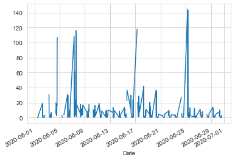

```python
# Based on the difference calculated from R
# we create a new column with absolute values to detect peaks
df["R_abs_dif"] = df.dif_R.abs()
df.R_abs_dif.plot()
```

```python
# Peak detection
from scipy.signal import find_peaks
peaks, properties = find_peaks(df.R_abs_dif, prominence=(df.R_abs_dif.max() * 0.4), width=1)
peaks_list = peaks.tolist()
# creating a new column with peaks detected
df["f3"] = df.R_abs_dif * 0
df.loc[df.index[peaks_list], "f3"] = 1
df.head()
```

| Date | I | V | P | G | MT | T | Clear Sky | PR | R | P_loss | f1 | dif_R | parzen | f2 | R_abs_dif | f3 |
| --- | --- | --- | --- | --- | --- | --- | --- | --- | --- | --- | --- | --- | --- | --- | --- | --- |
| 2020-06-01 06:30:00 | 1.168 | 26.5 | 30.9520 | 191.587644 | 18.326667 | 15.6 | False | 0.641431 | 22.688356 | 88.153122 | 0 | NaN | NaN | 0 | NaN | NaN |
| 2020-06-01 07:00:00 | 2.377 | 25.9 | 61.5643 | 394.809626 | 27.870000 | 17.6 | True | 0.644231 | 10.896088 | 42.335554 | 0 | NaN | NaN | 0 | NaN | NaN |
| 2020-06-01 07:27:00 | NaN | NaN | NaN | 499.719828 | 33.828333 | 18.4 | True | NaN | NaN | NaN | 0 | NaN | NaN | 0 | NaN | NaN |
| 2020-06-01 07:30:00 | 3.694 | 28.3 | 104.5402 | 510.039511 | 34.735000 | 18.7 | True | 0.872255 | 7.661072 | 29.766256 | 0 | -3.235015 | -0.239631 | 0 | 3.235015 | 0.0 |
| 2020-06-01 08:00:00 | 4.661 | 27.7 | 129.1097 | 611.360316 | 39.269492 | 19.3 | True | 0.916930 | 5.942931 | 23.090606 | 0 | NaN | -3.235015 | 0 | NaN | NaN |

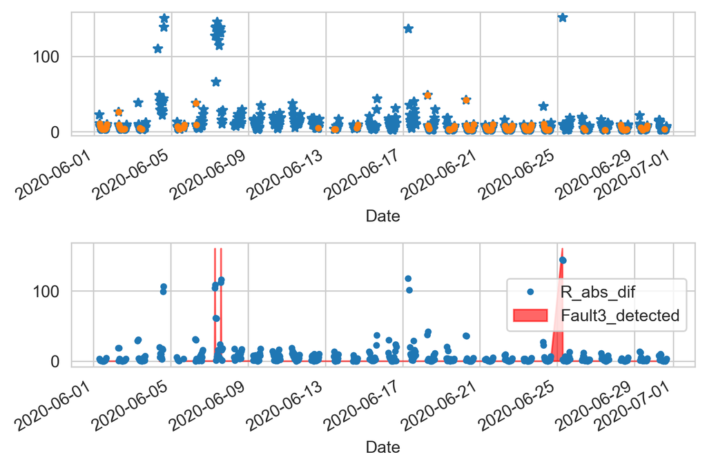

```python
fig, axes = plt.subplots(2,1,dpi=300)
df.R.plot(style="*", label="R", ax=axes[0])
R_ck.plot(style=".", label="R_ck", ax=axes[0])
df.R_abs_dif.plot(ax=axes[1],style=".")
axes[1].fill_between(df.index,
                     (160 * df.f3.values),
                         alpha=0.6, label="Fault3_detected", color="red")
plt.legend()
plt.tight_layout()
```

### Thoughts

There are many functions that can detect a change in the timeseries data. It is important to find tune the functions to be used.

## Additional info

An extra feature can be extracted from the timeseries data: Power loss, this could be also useful in case one want to detect power losses due to system resistances. It can be calculated as follows:

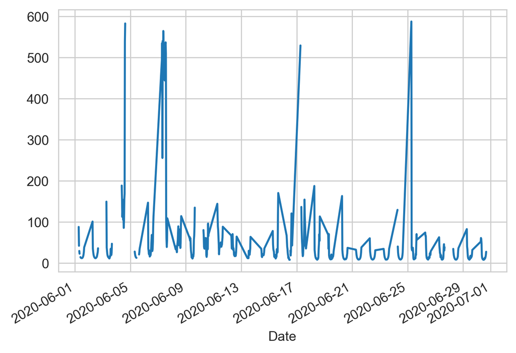

```python
Impp = 30.85
Vmpp = 7.94
df["P_loss"] = ((Impp * Impp) * df.R) / (Impp * Vmpp)
fig, axes = plt.subplots(dpi=300)
df.P_loss.plot()
```

Peak detection algorithms can be implemented to detect high power losses.